# Geostatisticsl Model

## Geostatistical Model

##### In-depth Articles

Gli obiettivi della Geostatistics sono molteplici, quali, per esempio, analizzare la struttura spaziale di un fenomeno $Y$, studiarne trend e autocorrelazione, prevederne i valori in aree in cui non è stata effettuata la rilevazione e campionare nuovi siti tenendo conto della dipendenza spaziale del fenomeno studiato. Il fenomeno di interesse viene misurato su un insieme di siti prefissati $s_1, …,s_n$ nella regione di studio $D \in R^2$. $Y(s)$ è denominata variabile regionalizzata e si intende il valore di $Y$ nel sito $s$. L’obbiettivo della Geostatistics è quello di inferire le carateristiche della variabile regionalizzata a partire dalle misurazioni effettuate, $Y(s_1), … , Y(s_n)$ sugli n siti campionari. Si assume che la dinamica del fenomeno studiato sia determinata da un processo aleatorio:
$$Y=\{ Y(s),\space s \in D \in R^2 \}$$
Occorre, poi, decomporre il processo aleatorio in tre componenti additive che mirano a rappresentare caratteristiche diverse del fenomeno modellizzato:
$$Y(s) = \mu(s) + z(s) + \epsilon(s)$$
Dove:

- $\mu(s)$ corrisponde alla componente deterministica e rappresenta la variabilità di larga scala ossia il trend spaziale del fenomeno (come si evolve il processo in media nello spazio)
- $Z(s)$ rappresenta la variabilità di piccola scala e rappresenta un processo aleatorio a media nulla sovrapposto al trend
- $\epsilon(s)$ rappresenta l’errore ed è una componente aleatoria a media nulla spazialmente incorrelata (white noise).

La larga e la piccola scala rappresentano la componente regolare del fenomeno mentre l’errore rappresenta il disturbo.

$$dato \space spaziale = variabilita' \space di \space larga \space scala \space + \\ + \space variabilita' \space di \space piccola \space scala \space + \\ (+ \space variabilita' \space di \space micro \space scala \space +) \\ + \space errore$$

# Componente di larga scala metodi di stima

La componente di larga scala rappresenta la tendenza di fondo del processo. Esistono due approcci per stimare questa componente di trend: un approccio di tipo parametrico ed uno di tipo non parametrico. Nel primo caso si assume noto un modello funzionale che lega il valore atteso alle coordinate delle locazioni. Nell’approccio non parametrico non si fa alcuna assunzione sulla forma analitica che lega la funzione media della variabile regionalizzata alle coordinate dei siti di rilevazione né alla sua natura aleatoria.  
Per quanto riguarda i metodi parametrici come regressione lineare o polinomiale si lascia agli articoli dedicati mentre di seguito si andrà ad analizzare un semplice modello non parametrico che, nonostante la sua semplicità, risulta spesso più che sufficienti a spiegare le dinamiche aleatorie del processo spaziale.

### LOESS

Il metodo dei polinomi locali noto anche come metodo LOESS, abbreviazione di LOcal regrESSion, viene impiegato per adattare una superficie di regressione ai dati attraverso una procedura di smoothing (lisciamento).

L’Analysis di regressione è un modo per quantificare la relazione esistente tra una variabile di risposta Y ed una o più variabili esplicative. Si supponga che, data una variabile di risposta Y ed un insieme di $p$ variabili esplicative $x = (x_1, …, x_p)$ fissate, la relazione fra $Y$ e $x$ sia data da:
$$Y = m(x) + \epsilon$$
Nel contesto dei trend spaziali x è da intendersi come il vettore s delle coordinate di un punto nella regione di studio D, mentre $\epsilon$ costituisce il termine di errore. L’assunzione di una struttura polinomiale del predittore può essere eccessivamente semplificatrice se mantenuta fissa su tutto il modello mentre in LOESS questa viene considerata localmente su un intorno di x. In un primo momento si spiegherà questo metodo nel caso univariato per poi estendere la definizione al caso multivariato (che difatti è quello spaziale). Il metodo LOESS permette di ottenere un valore $\hat y_0$ differenziando il ruolo delle rilevazioni presenti nel campione e in modo tale che le osservazioni più vicine a $x_0$ abbiano un peso maggiore da quelle che invece si trovano da esso distanti. In questo approccio occorre quindi definire un’opportuna metrica delle esplicative per quantificare la distanza tra $x_0$ el le altre $x_k$ con $k= 1,…,n$. Si supponga che la relazione tra il valore atteso della risposta e c sia data in un intorno ragionevolmente piccolo di z da un polinomio di grado $q$, quindi il modello viene formalizzato come:

$$m(x) = \beta_0 + \beta_1(x) \space x + \beta_2(x) \space x^2 + … + \beta_q(x) \space x^q$$

Per calcolare la stima di $m (x) $ occorre calcolare le stime dei parametri del polinomio $\beta_j(x)$. Qeste stime sono ottenute applicando i minimi quadrati ponderati e, quindi, i $\hat \beta_j(x)$ sono i valori $\beta_j =\beta_j(x)$ che minimizzano:
$$\sum \bigg\{w_k(x) \space \space (y_k -\beta_0 -\beta_1 x_k - … - \beta_q x_k^q)^2 \bigg\}$$
Sove I valori $ w_k(x)$ sono degli opportuni pesi definiti in basse alla distanza di ciascun punto del campione $x$

Per questo si ricorre ad opportune funzioni nucleo dette anche, utilizzando la denominazione inglese ormai generalmente diffusa, kernel. La funzione kernel deve avere alcuni requisiti che la rendano idonea a definire un sistema di ponderazione. In particolare, deve essere positiva, con un massimo in 0 e simmetrica rispetto a questo valore. In via di principio qualsiasi funzione con queste caratteristiche potrebbe essere utilizzata per definire i pesi. Tuttavia, la funzione dei pesi cui tipicamente si fa riferimento nel LOESS è la funzione tricubica:

$$W(u) = \begin{cases} (1-|u|^3)^3, & \mbox{se } -1 \leq u \leq 1 \\ 0, & \mbox{altrimenti} \end{cases}$$

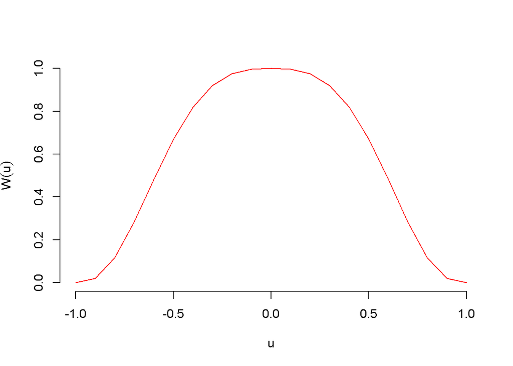

Questa funzione è una funzione a supporto compatto, con un massimo in 0 e simmetrica rispetto a questo valore.

Il peso da assegnare alla k-esima osservazione campionaria nella stima della regressione in x è ottenuto come :
$$w_k(x) = W\bigg(\frac{x_k-x}{h}\bigg)$$

Dove h è un parametro positivo che rappresenta la finestra di lisciamento, ovvero l’ampiezza dell’intervallo scelto attorno a x entro cui i punti campionari assumono un peso positivo nella stima di m(x). Nella stima LOESS, diversamente da altri metodi di lisciamento, la scelta della finestra non è fissa, ma varia a seconda del punto x. Più in particolare, h viene scelto fissando la percentuale di punti $\frac{c}{n}$ (detta span) utilizzati per il lisciamento, in modo tale che l’ampiezza della finestra si modifica da x a x al fine di garantire che venga utilizzato sempre lo stesso numero c di valori campionari nella stima di m(x) per diverse scelte di x. Tanto più lo span è piccolo, tanto più locale sarà la stima e, quindi, meno liscia la superficie. Tanto più grande è il valore dello span tanto più liscia sarà la superficie prodotta e tanto “meno locale” la stima.

Se x è un vettore in $R^p$ e $d(u,v)$ una metrica di ale spazio per esempio la distanza euclidea tra due punti allora il peso di $w_k(x)$ da attribuirsi all’osservazione (y_k,x_k) ciene definita tramite la funzione $w_k(x)=W\bigg(\frac{d(x,x_k)}{h}\bigg)$

# Componente di piccola scala metodi di stima

*Prima legge della geografia: “Everything is related to everything else but near things are more related than distant things” (Tobler, 1970).*

Il fenomeno considerato è caratterizzato da una dipendenza o regolarità spaziale. Teoria delle Variabili Regionalizzate di Matheron (1965) i valori delle Variabili Regionalizzate tendono ad essere correlati (luoghi più vicini sono più simili ad altri maggiormente distanti) a certe scale. La teoria di Matheron quantifica questa correlazione.

Intuitivamente si parla di dipendenza positiva se l’attributo Y assume un valore “grande” (o “piccolo”) in un sito allora tende ad assumere un valore elevato (o limitato) anche in siti vicini (è possibile anche una dipendenza negativa, anche se molto rara).

[figure not shown]

Un approccio per descrivere la dipendenza spaziale è rappresentato dal variogramma. Non è una misura di correlazione ma indica una misura di variabilità del processo:

$$2 \gamma(h)= Var[S(x+h)-S(x)] \\ \gamma(h) = semi\space variogramma$$

Il Variogramma consiste in un modello di dipendenza spaziale, che descrive la varianza dei dati tra due posizioni e la loro distanza di separazione. Usando il Variogramma e diverse tecniche di interpolazione, (ad esempio il Kriging), la variabile può essere stimata in pozioni in cui non è stata campionata

## Variogramma empirico (Introduzione)

É possibile capire meglio il Variogramma guardando la nuvola di punti che si genera rappresentando graficamente le semivarianze di tutte le coppie di osservazioni:

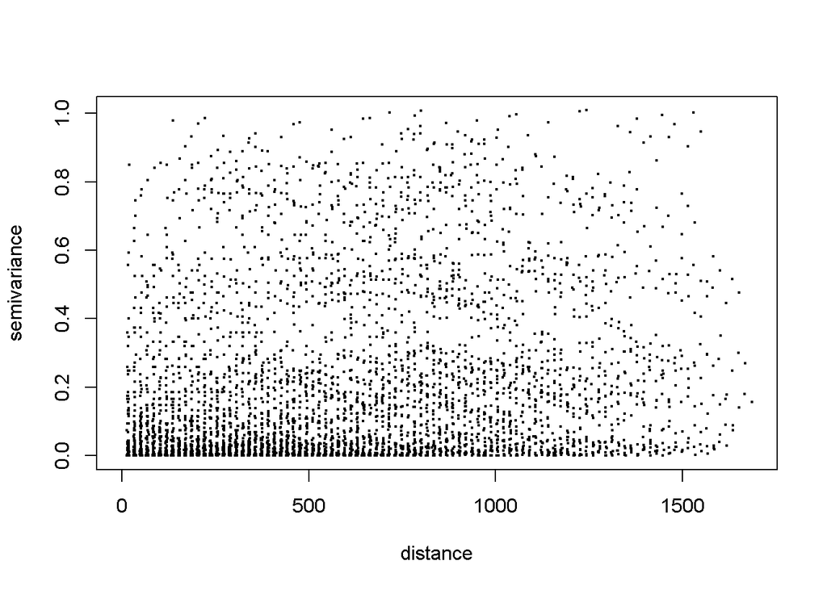

Ogni punto rapprensenta un paio di dati osservati, sull’asse X c’è la distanza (metri), mentre sull’asse Y c’è la varianza. La nube di punti contiene tutte le relazioni spaziali nei dati per tutte le possibili distanze tra i campioni, ma non è una funzione continua. E’ difficie interpretarla e comprendere l’esistenza di correlazioni spaziali. Si rende necessario prendere in considerazione un numero ristretto di lag (distanze). In questo modo sono più riconoscibili gli outlier ed è possibile modellizzare la distribuzione spaziale

Il variogramma è semplicemente una rappresentazionesintetica (media) della nuvola di punti delle semivarianze vs distanze. Una funzione per modellare è necessaria per ottenereun valore di varianza per ogni possibile distanza tra i dati alle posizioni note e le posizioni che devono essere predette.

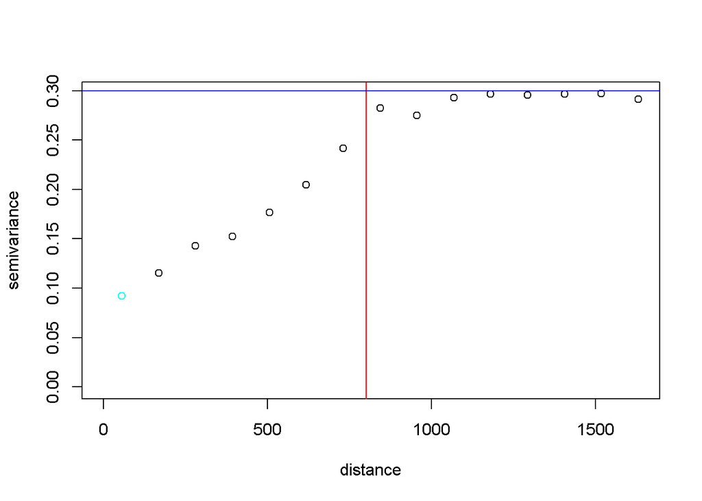

- Il nugget rappresenta le variazioni casuali, della variabilità su piccola scala (inferiore cioè alla scala del campionamento), la variazione che ci sarebbe tra due punti più vicini rispetto alla distanza minima dei punti campionati.
- Il range corrisponde alla distanza in cui il semivariogramma (in un modello stazionario) raggiunge un valore costante detto sill. Intuitivamente è la massima distanza per cui due punti possono essere considerati spazialmente correlati.
- La soglia (sill) rappresenta la varianza massima tra i punti misurati, che per modelli stazionari corrisponde alla varianza di campionamento.

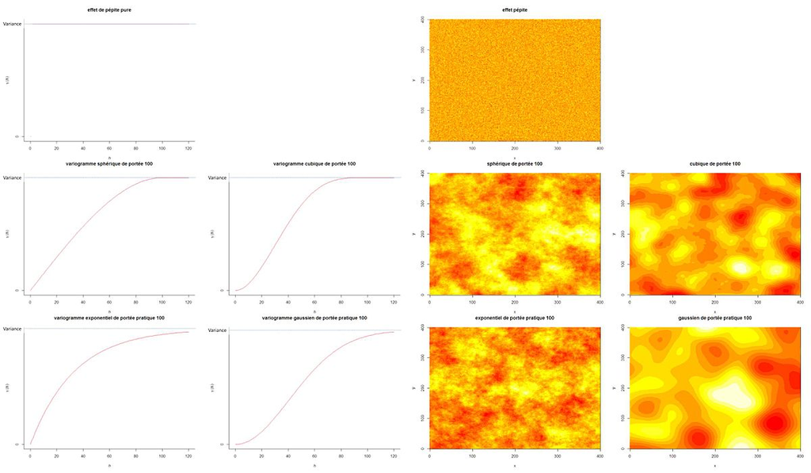

  Come si evidenzierà meglio in seguito il variogramma empirico è uno stimatore del variogramma del processo che risulta adeguato in situazioni di Stationarity intrinseca

### Effetto pepita (Nugget effect)

  $\hat \gamma(h)$ assume valori diversi da 0 in prossimità di h = 0 pur essendo per definizione $(0)=0 $ quindi anche a piccole distanze ci sono forti variazioni nella variabile rilevata (isotropia).

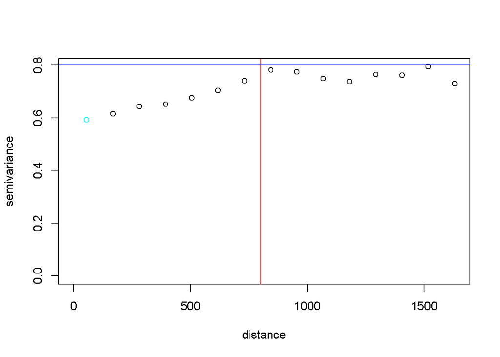

### Hole effect

  caduta rapida dei valori del variogramma empirico quando la distanza aumenta valori a maggiori distanze sono loro più simili di valori a distanze ridotte, possibili cause sono: presenza di trend, presenza di valori anomali, correlazioni negative o periodicità.

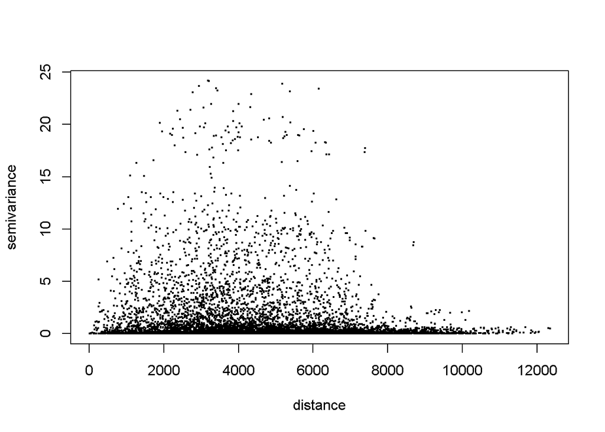

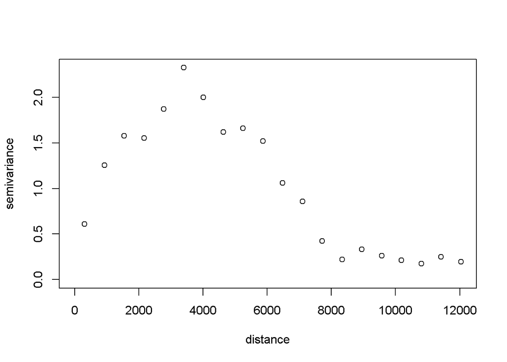

  La stima del variogramma può essere realizzata seguendo un approccio di tipo non parametrico o parametrico. Il parte seguente è dedicata alla stima non parametrica del variogramma e la successiva alla stima parametrica.

# STIMA DEL VARIOGRAMMA EMPIRICO

## Il metodo dei momenti (MOM) [Matheron, 1962]

I variogramma empirico mette in relazione i valori osservati delle variabili di interesse con la posizione reciproca delle locazioni in cui sono rilevate. In particolare confronta per differenza coppie di valori presi a distanza h:

$$2 \hat \gamma (h) = \frac{1}{\#N(h)} \space \space \sum_{s_i,s_j \in N(h)}\bigg(Y(s_i)-Y(s_j)\bigg)^2$$

… e di conseguenza il semi-variogramma risulta:

$$\hat \gamma (h) = \frac{1}{2\space \space \#N(h)} \space \space \sum_{s_i,s_j \in N(h)}\bigg(Y(s_i)-Y(s_j)\bigg)^2$$
dove $N(h)$ contiene tutte le locazioni che distano h tra loro

**Proprietà:**

- $\hat \gamma(h)=\hat \gamma (-h)$ (come per il variogramma teorico)
- Correttezza:
  $$E[\hat \gamma (h)]= \hat \gamma (h)$$
- Consistenza:
  $$Corr\bigg\{ \bigg(Y(s + h)-Y(s)\bigg)^2 \space \space , \space \space \bigg(Y(s' + h)-Y(s')\bigg)^2\bigg\} \approx 0$$
  Da questa proprietà di consistenza ne deriva che per la legge dei grandi numeri
  $$\hat \gamma (h) \rightarrow^d \space \space Normale \space Multivariata$$
  Questa convergenza è tanto piu veloce quanto la proprietà di consistenza è verificata, ossia, avviene lentamente più le osservazioni sono correlate mentre se le osservazioni risultano incorrelate allora il semivariogramma convergerà in distribuzione ad una Normale Multivariata in modo più rapido

In R si utilizza la funzione `variog` nel pacchetto `geoR` inserendo il dataset trasformato in un elemento geodata e imponento il parametro `estimator.type = “classical”`

## Stima robusta del varogramma empirico [Cressie e Hawkins, 1980]

I variogramma empirico mette in relazione i valori osservati delle variabili di interesse con la posizione reciproca delle locazioni in cui sono rilevate. In particolare confronta per differenza coppie di valori presi a distanza h:

$$2 \gamma^* (h) = \bigg[ \frac{1}{\#N(h)} \space \space \sum_{s_i,s_j \in N(h)}\bigg|Y(s_i)-Y(s_j)\bigg|^
{\frac 1 2}\bigg]^4$$

Questo metodo nasce con l’obiettivo di ridurre l’impatto degli outlier. La potenza $4^a$ consente di ritornare alla scala di $2 \gamma^* (h)$.

Per ottenere una versione più resistente si utilizza al posto della media la mediana:

$$2 \tilde \gamma (h) = \frac{Med \bigg[ \bigg|Y(s_i)-Y(s_j)\bigg|^{\frac 1 2}\bigg]^4}{B(h)} \\ dove: \\ B(h)= 0.457 \rightarrow \mbox{fattore di correzione} \\ s_i,s_j \in N(h)$$

In R si utilizza la funzione `variog` nel pacchetto `geoR` inserendo il dataset trasformato in un elemento geodata e imponento il parametro `estimator.type = “modulus”`, in questa funzione lo stimatore risulta leggermente lo stesso ma viene calcolato utilizzando le proprietà del Modified Z-Scores:

## Stimatore kernel del variogramma [Nadaraya-Watson, 1964]

$$2 \bar \gamma (h,u) = \sum_{i, \space j}^{\#N(h)}\space w_{i\space j}\bigg(Y(s_i)-Y(s_j)\bigg)^2 \\ con: \\ \sum w_{i, \space j}=1\\0<w_{i,\space j}<1$$

I pesi sono ottenuti dalla funzione kernel $K(u)$

$$w_{i, \space j}=w(s_i,s_j,d)= \frac{K\bigg((h- ||s_i - s_j||)/d\bigg)}{\sum_{s_i,s_j \in N(h)} K\bigg((h- ||s_i - s_j||)/d\bigg)}$$

$d$: è il parametro di lisciamento.

In R si utilizza la funzione `variog` nel pacchetto `geoR` inserendo il dataset trasformato in un elemento geodata e imponento il parametro `op=“sm”`

## Stima di massima verosimiglianza del variogramma (ML)

Questo metodo si basa sulla massimizzazione della funzione di verosimiglianza del campione. Occorre quindi specificare la distribuzione congiunta delle osservazioni campionarie. Tipicamente questo approccio è relativamente agevole assumendo che il processo $Y(s)$ sia un PSS gaussiano (isotropico). Solitamente la distribuzione congiunta del campione è una normale multivariata il cui vettore delle medie e la cui matrice di varianza e covarianza sono data dalla funzione della media e dal covariogramma del processo.  
La funzione di log-verosimiglianza tipicamente assume una forma complessa e l’ottimizzazione non può essere risolta per via analitica, ma viene ottenuta numericamente tramite procedure iterative. L’approccio usualmente adottato in questo caso è quella della profilatura della verosimiglianza.

In R si utilizza la funzione `likfit` nel pacchetto `geoR` inserendo il dataset trasformato in un elemento geodata e imponento il parametro `cov.model=“exponential”` e inizializzando i due paramtri (media e covarianza) con `ini.cov.pars=c(par1,par2)`  
IMPLEMENTAZIONE IN R  
`likfit(dat.om.geo,ini.cov.pars=c(par1,par2),`  
`cov.model=“exponential”,trend=“cte”, fix.nugget=FALSE,nugget=20,`  
`nospatial=FALSE,messages=T)`

## Stima dei minimi quadrati del variogramma

Il metodo dei minimi quadrati, utilizzato in questo contesto consiste nell’interpolazione del variogramma empirico tramite un modello parametrico. In questo caso non occorre dare alcuna assunzione circa la distribuzione del processo a parte richiedere che sia intrinsecamente stazionario.

Per ottenere lo stimatore in questione serve per prima cosa stimare preliminarmente il variogramma empirico poi serve una valutazione grafica per individuare una o più famiglie parametriche che ne colgano le caratteristiche salienti. infine, si procede all’interpolazione della curva cercando la stima del vettore $\theta$ che rende minima la distanza tra i punti del variogramma empirico e la curva teorica scelta. piu precisamente calcolato il variogramma empirico a distanze prescelte si considera il vettore dei valori dipendenti dal vettore dei parametri ignoti assunti dal modello parametrico scelto in corrispondenza delle distanze prefissate.

### Minimi quadrati ordinari (OLS)

Con il metodo dei minimi quadrati ordinari occorre come prima cosa stimare attraverso il metodo MOM il variogramma empirico:

$$2 \hat \gamma(h)= \{2 \hat \gamma(h_1), ...,2 \hat \gamma(h_k) \} \space \space \in R^k$$

Si procede ad una valutazione grafica e si individua una famiglia parametrica che possa spiegare la variabilità del variogramma empirico (cogliere le caratteristiche salienti).

Valori assunti da un vaido modello parametrico su K lag

$$2 \gamma(h, \theta)= \{2 \gamma(h_1, \theta), ...,2 \gamma(h_k, \theta) \} \space \space \in R^k$$

Lo stimatore dei minimi quadrati ordinati è definito in questo contesto come:

$$\hat \theta_{OLS} = \min_{\theta}\{||2 \gamma(h, \theta) -2 \hat \gamma(h)|| \} =\\= \min_{\theta}\bigg\{ \sum_{i=1}^k [2 \gamma(h_i, \theta)- 2 \hat \gamma(h_i)]\bigg\}$$

Al posto del metodo MOM si possono utilizzare stime più robuste per aumentare la robustezza delle stime OLS. La procedura può essere applicata anche per i variogrammi direzionali, gli OLS non sono completamente soddisfacenti in quanto ignorano l’eteroschedasticità del variogramma empirico ai vari lag.

```
IMPLEMENTAZIONE IN R
 variofit(geodata,
        ini.cov.pars=c(par1,par2),
          cov.model="exponential",
          fix.nugget=FALSE,nugget=20,
          weights = "equal" )
```

### Metodo dei minimi quadrati ponderati (WLS)

Il metodo OLS non tiene conto della correlazione esistente tra le stime dei valori del variogramma empirico e le diverse distanze $h_i$ e ignora l’eteroschedasticità di tali stime.

Per superare questi problemi può essere utile, sebbene computazionalmente più oneroso, ricorrere ai minimi quadrati generalizzati (*GLS*). In questo caso lo stimatore di $\theta$ è dato da:

$$\hat \theta_{GLS} = \min_{\theta}\{[ \gamma(h, \theta) - \hat \gamma(h)]^T \space \space W(\theta)^{-1} \space \space [ \gamma(h, \theta) - \hat \gamma(h)] \} \\dove: \\ W(\theta)= diag\{Var[\hat \gamma(h_1)], ... , Var[\hat \gamma(h_k)]\}$$

Problemi nella determinazione dei GLS si possono incontrare quando $W(\theta)^{-1}$ non è noto, infatti, una qualunque procedura di ottimizzazione non lineare fornisce i risultati desiderati, quanto nell’identificazione di forme esplicite per le covarianze in questione necessarie al calcolo dei pesi.

Una espressione più agevole per il sistema dei pesi è fornita considerando l’approssimazione:

$$Var[\hat \gamma(h_i)] \approx \frac{2 \space (\gamma(h_i, \theta))^2}{\#N(h_i)}$$
che vale in modo esatto nel caso di un processo gaussiano con incrementi al quadrato incorrelati. Lo stimatore WLS è allora ottenuto come:

$$\hat \theta_{WLS} = \min_{\theta}\bigg\{ \sum_{i=1}^k \space (\#N(h_i))\space \bigg(\frac{2 \space \hat \gamma(h_i)-2 \space \gamma(h_i, \theta)}{2 \space \gamma(h_i, \theta)} \bigg)^2 \bigg\}$$

Il sistema dei pesi in questo caso è, intuitivamente, molto ragionevole, infatti, le distanze $h_j$ a cui corrisponde un elevato numero di coppie di siti campionari, $\#N(h_j)$, contribuiscono maggiormente alla stima, essendo lo scarto $2 \space \hat \gamma(h_i)-2 \space \gamma(h_i, \theta)$ al numeratore pesato maggiormente.

In corrispondenza di queste distanze, d’altra parte, le stime fornite dal variogramma empirico possono essere ritenute particolarmente affidabili dato l’elevato numero di rilevazioni campionarie. In secondo luogo il sistema dei pesi, per effetto della presenza del variogramma al denominatore (che tipicamente tende ad assumere valori piccoli in corrispondenza di distanze piccole), assegna un peso maggiore agli scarti relativi a distanze vicine 0 dove la dipendenza spaziale è, solitamente, più rilevante.

```
IMPLEMENTAZIONE IN R
 variofit(geoadata,
        ini.cov.pars=c(par1,par2),
          cov.model="exponential",
          fix.nugget=FALSE,nugget=20)
```

**Osservazioni**  
I LS richiedono la conoscenza di una stima preliminare del variogramma, gli ML no ma gli stimatori ML tendono ad essere distorti soprattutto per campioni piccoli. LS più robusti di ML ma ML più efficienti se l’assunzione di normalità è (ragionevolmente) verificata.

# Valutazione della variabilità del variogramma con MC

**Gaussian Geostatisticsl Simulations**

La funzione `grf` (sempre nel pacchetto `geoR`), che sta per Gaussian Random Fields, genera simulazioni di campi casuali gaussiani su insiemi regolari o irregolari di posizioni.

Una volta stimato il variogramma si possono inserire i parametri del Processo stocastico ottenuti e replicare $B \gg 0$ valori da questo PPS, con questo poi è possibile rappresentare graficamente molteplici variogrammi cosi da riuscire ad ottenere una stima della vaiabilità di questo stimatore.

**Esempio**

```r
set.seed(123)
n<-200
m<-grf(n=n, cov.pars=c(37, 42),nsim=50,nugget=11,xlim=c(0,150),ylim=c(0,115))
```

```
## grf: simulation(s) on randomly chosen locations with  200  points
## grf: process with  1  covariance structure(s)
## grf: nugget effect is: tausq= 11
## grf: covariance model 1 is: exponential(sigmasq=37, phi=42)
## grf: decomposition algorithm used is:  cholesky
## grf: End of simulation procedure. Number of realizations: 50
```

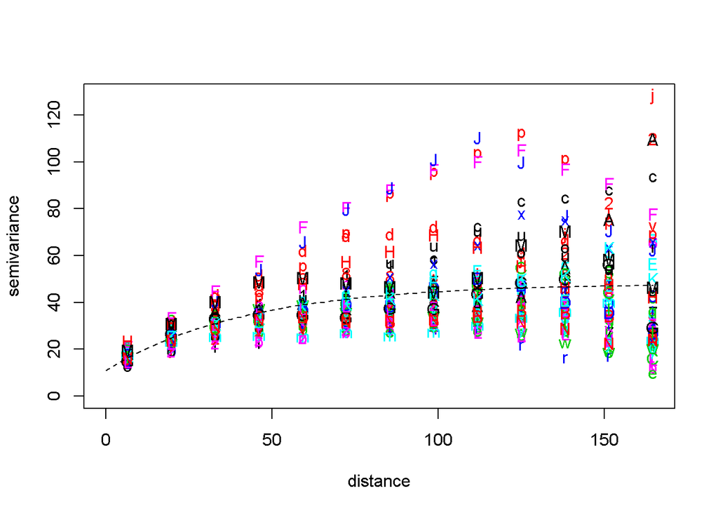

```r
plot(m)
```

# Il variogramma empirico in presenza di trend

L’Analysis del variogramma finora esposta assume implicitamente che il processo sia stazionario in meda. In molte applicazioni la variabile regionalizzata presenta dei trend sulla regione d’interesse e il variogramma empirico stimato come si è visto risulterebbe distorto. La soluzione più diffusa per risolvere questa problematicità consiste nell’operare una detrendizzazione dei dati preliminarmente alla stima del variogramma. In presenza di trend si può infatti ipotizzare che i dati siano generati trascurando la componente white noise dal processo, quindi il processo diventa una funzione deterministica. Per questa ragione una stima della componente di piccola scala può essere ottenuta tramite il vettore dei residui dopo aver effettuato la stima del trend. Nell’effettuare la stima è opportuno utilizzare dei trend semplici ovvero non funzioni eccessivamente flessibili in quanto si rischierebbe altrimenti di catturare (impropriamente) una grossa quantità di variabilità spaziale nella componente di larga scala, infatti, una componente di larga scala troppo flessibile può cogliere componenti di piccola scala. Solitamente si scelgono polinomi di basso grado nelle coordinate dei punti di rilevazione.

In R nel pacchetto `geoR` per impostare la presenza di un trend occorre modificare nelle sezioni delle funzioni il parametro `trend=`:

- `“cte”` (di default) la media è considerata constante:
  $$\mu(x) = \mu$$
- `“1st”` la media è considerata un polinomio di primo grado delle coordinate:

  $$\mu(x) = \beta_0 + \beta_1*x_1 + \beta_2*x_2$$
- `“2nd”` la media è considerata un polinomio di secondo grado delle coordinate:

  $$\mu(x)= \beta_0 + \beta_1*x_1 + \beta_2*x_2 + \beta_3*(x_1)^2 + \beta_4*(x_2)^2 + \beta_5*x_1*x_2$$
- $\sim model$ si può specificare un altro modello a scelta.

# Piccolo approfondimento: Il covariogramma empirico

**Il covariogramma**

$$\rho(h) = Corr(S(x),S(x+h)) \space \space \space \space x, x + h \in A$$

Relazione tra correlogramma e covariogramma: $\rho(h)=\frac{C(h)}{C(0)}$

**Il covariogramma empirico**

$$\hat C (h) = \frac{1}{\#N(h)} \space \space \sum_{s_i,s_j \in N(h)}\bigg[Y(s_i)-\overline Y\bigg]\space \bigg[Y(s_i)-\overline Y\bigg] \\con: \overline Y=\frac{\sum_{I=1}^n Y(s_i)}{n}$$

Il covariogramma empirico è una stima distorta con Bias. In generale lavorare sul variogramma è preferibile perché richiede assunzioni più deboli sul processo inoltre il covariogramma richiede la stima della media quindi risulta più sensibile del variogramma alla presenza di trend.

N.B. Non si può stimare il variogramma empirico tramite il covariogramma empirico attraverso la relazione che sussiste tra variogramma e covariogramma in quanto la stima è distorta.